# Lab 2

Alex Ziyu Jiang

# Bayesian Binomial Models

In lecture we looked at a Bayesian binomial model on a dataset about labor market data. Today we look at its use on a different dataset. First, we download the package for the dataset:

```r
# install.packages("devtools") # run it for the first time
devtools::install_github("carloscinelli/generalizing")
```

## The dataset

Here we will be looking into three experiments that were designed to study the effects of vitamin A supplementation on childhood mortality. Three trials were carried outt in Aceh, West Java and Sarlahi. Based on scientific background, Vitamin A reduces childhood mortality by reducing the incidence, severity or duration of life-threatening diseases such as measles and diarrhea. We focus on the following measures:

- The outcome of the trial: Survival and death during the trial.
- The treatments: Treatment group if assigned vitamin A; control if assigned placebo.

## The model

We are interested to study the contrast of survival rates between treatment and control groups and we can build a Bayesian model to study the differences. We denote $P_1$ as the survival rate in the treatment group, we further assume that the death of each subject in the treatment group is independent of each other and identical with probability $1-P_1$ (which is the mortality rate). Suppose the total number of participants in the treatment group is $N_1$, the number of participants survived is $n_1$ (for the Aceh case, it will be $N_1 = 12,991, n_1 = 12,890$). Thus we can build a **binomial model** to characterize the number of participants surviving, in the treatment group:

$$\begin{align*}
n_1 &\sim \text{Binom}(N_1,P_1)
\end{align*}$$

We can do the similar thing for the control group and have the following model:

$$\begin{align*}
n_1 &\sim \text{Binom}(N_1, P_1) \\
n_0 &\sim \text{Binom}(N_0, P_0)
\end{align*}$$

Additionally, we should notice that $P_0, P_1$ are unknown values so we need to place priors on it in order to make it a Bayesian model. Keep in mind that they are essentially probabilities between zero and one, so it would make sense to give them a uniform prior on $[0,1]$, without extra prior information.

## The inference goal

There are a couple of quantities of interest that we would want to conduct inference on from this model. Obviously we want to look at the posterior distribution of $P_0, P_1$, the survival rates for the treatment and the control group, and we would also want to look at the **risk difference** $RD = (1-P_1) - (1-P_0) = P_0 - P_1$, the **risk ratio** $RR = \frac{1 - P_1}{1 - P_0}$, the **survival ratio** $1 - \frac{1 - P_1}{1 - P_0}$. The survival ratio can be interpreted as the percentage of children that were saved due to vitamin A supplementation.

## The Jags implementation

```r
library(rjags)
library(rethinking)
library(generalizing)
library(rstan)
# install.packages("devtools")
data("Aceh")
# JAGS code
model_code <- "
  model{
    # likelihood
    n1 ~ dbinom(P1, N1)
    n0 ~ dbinom(P0, N0)
    # prior
    P1 ~ dunif(0, 1)
    P0 ~ dunif(0, 1)
    # transformed quantities
    rd <- P0 - P1
    rr <- (1-P1)/(1-P0)
    sr <- (P1-P0)/(1-P0)
    nrd <- P1 - P0
  }
"
# compile jags model
model <- jags.model(file = textConnection(model_code),
                    data = Aceh)
```

[output not shown]

```r
samples <- coda.samples(model,
                        variable.names = c("P1", "P0", "rd", "rr", "sr", "nrd"),
                        n.iter = 1e4)
```

[output not shown]

```r
samples <- as.data.frame(samples[[1]])
precis(samples, digits = 10)
```

```
'data.frame': 10000 obs. of 6 variables:
```

|  | mean | sd | 5.5% | 94.5% | histogram |
| --- | --- | --- | --- | --- | --- |
| P0 | 0.98927073 | 0.0009652906 | 0.9876841291 | 0.9907521943 | ▁▁▁▁▂▃▇▇▇▅▂▁▁▁ |
| P1 | 0.99215486 | 0.0007889162 | 0.9908464944 | 0.9933540013 | ▁▁▁▁▂▃▇▇▇▃▁▁▁▁ |
| nrd | 0.00288413 | 0.0012439772 | 0.0008938617 | 0.0048747404 | ▁▁▁▁▃▇▇▃▁▁▁▁ |
| rd | -0.00288413 | 0.0012439772 | -0.0048747404 | -0.0008938617 | ▁▁▁▁▃▇▇▃▁▁▁▁ |
| rr | 0.73710814 | 0.0997447909 | 0.5906634460 | 0.9074780409 | ▁▁▁▇▇▃▁▁▁▁ |
| sr | 0.26289186 | 0.0997447909 | 0.0925219591 | 0.4093365540 | ▁▁▁▁▃▇▇▁▁▁ |

## STAN code

Similarly, we can repeat the analysis in STAN. We can see from the results that they are very similar to each other.

[output not shown]

[output cut: 165 more lines]

[output not shown]

```
Inference for Stan model: rt_cmdstanr_82ccf439e6ee2a6b08997cf2f7060755-202204071410-1-5727e1.
1 chains, each with iter=10000; warmup=5000; thin=1;
post-warmup draws per chain=5000, total post-warmup draws=5000.

         mean se_mean   sd     2.5%      25%      50%      75%    97.5% n_eff
P1       0.99    0.00 0.00     0.99     0.99     0.99     0.99     0.99  3575
P0       0.99    0.00 0.00     0.99     0.99     0.99     0.99     0.99  3675
rd       0.00    0.00 0.00    -0.01     0.00     0.00     0.00     0.00  3857
rr       0.74    0.00 0.09     0.57     0.67     0.73     0.80     0.93  3799
sr       0.26    0.00 0.09     0.07     0.20     0.27     0.33     0.43  3799
lp__ -1321.35    0.02 0.98 -1324.01 -1321.70 -1321.07 -1320.66 -1320.40  2178
     Rhat
P1      1
P0      1
rd      1
rr      1
sr      1
lp__    1

Samples were drawn using NUTS(diag_e) at Thu Apr 07 14:10:10 2022.
For each parameter, n_eff is a crude measure of effective sample size,
and Rhat is the potential scale reduction factor on split chains (at
convergence, Rhat=1).
```

```
ci_level: 0.8 (80% intervals)
outer_level: 0.95 (95% intervals)
```

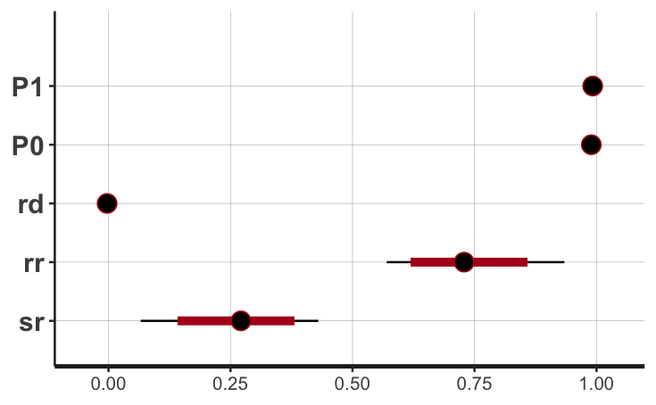

# In class exercise

# References

Cinelli C, Pearl J. Generalizing experimental results by leveraging knowledge of mechanisms. Eur J Epidemiol. 2021 Feb;36(2):149-164. doi: 10.1007/s10654-020-00687-4. Epub 2020 Oct 18. PMID: 33070298.